# Imagination Exercise

RCT and DAGs

Author

Affiliation

David Sneddon

Old Dominion University

### Research Setting

Attention Deficit Hyperactivity Disorder (ADHD) was added to the DSM-III in 1987. Diagnosis of this condition became commonplace in the 1990’s. (Holland 2024) I am interested in the effect of early pediatric intervention on finishing a baccalaureate degree. I will define early pediatric intervention as at age 14 or younger. The according to the Centers for Disease Control and Prevention (n.d.) there are three classifications of treatment: Behavioral therapy, medication with stimulants, and medication with non stimulants.

### Application Description

I made assumptions for potential causes for intervention indicated in the DAG below. I identified two backdoors that I will control for in the model. First is “Means” which can be controlled for by income level. Second is whether at least one parent held a baccalaureate degree. I also included some other possible factors that could complicate earning the degree but ultimately these factors will not need to be controlled for.

Directed Acyclic Graph (DAG):

```r
library(dagitty)
adhd_dag <- dagitty("dag {
                    Intervention [exposure]
                    Degree [outcome]
                    WorkEthic [unobserved]
                    Talent [unobserved]
                    Means -> Degree
                    Means -> Intervention
                    Intervention -> Degree
                    ParentDegree -> Degree
                    ParentDegree -> Means
                    ParentADHD -> Trauma
                    Trauma -> Comorbidity
                    Comorbidity -> Intervention
                    ParentADHD -> Intervention
                    Poor -> Trauma
                    ParentADHD -> Poor
                    ParentDegree -> Intervention
                    Talent -> HSGPA
                    WorkEthic -> HSGPA
                    HSGPA -> Degree
                    Trauma -> Intervention
                    Means -> HSGPA
                    ParentDegree -> HSGPA
                    }")
plot(adhd_dag)
cat("Adjustment Set for DAG:\n")
print(adjustmentSets(adhd_dag, effect = "direct"))
paths(adhd_dag)
```

**Output**

```
Adjustment Set for DAG:
{ Means, ParentDegree }
$paths
 [1] "Intervention -> Degree"
 [2] "Intervention <- Means -> Degree"
 [3] "Intervention <- Means -> HSGPA -> Degree"
 [4] "Intervention <- Means -> HSGPA <- ParentDegree -> Degree"
 [5] "Intervention <- Means <- ParentDegree -> Degree"
 [6] "Intervention <- Means <- ParentDegree -> HSGPA -> Degree"
 [7] "Intervention <- ParentDegree -> Degree"
 [8] "Intervention <- ParentDegree -> HSGPA -> Degree"
 [9] "Intervention <- ParentDegree -> HSGPA <- Means -> Degree"
[10] "Intervention <- ParentDegree -> Means -> Degree"
[11] "Intervention <- ParentDegree -> Means -> HSGPA -> Degree"

$open
 [1]  TRUE  TRUE  TRUE FALSE  TRUE  TRUE  TRUE  TRUE FALSE  TRUE  TRUE
```

**Plot**

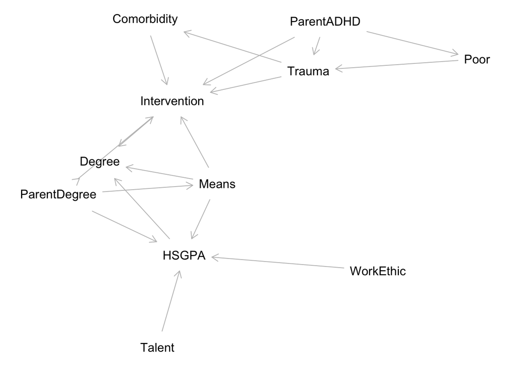

### Data Description

Ultimately, I will need to collect a sample from adults that have an ADHD diagnosis and determine the age of their intervention, their family’s average income during their childhood, and whether at least one of their parent’s have a college degree, and of course whether they earned a bachelor’s degree. For the purposes of this test, I would consider a bachelor’s degree as a positive result if earned before the age of 25. I don’t want to test for non-traditional students such as adult learners. A positive result on early interventon would be some at or before the age of 14, the typical age a child enters high school.

### Empirical Model

Positive result on degree $D$ for subject $n$ modeled as:

$$D_n = \beta_0 + \delta_1I_n + \delta_2P_n+ \beta_1M_n + \varepsilon_n$$

### (Expected) Findings

I expect that early intervention will improve the chances of obtaining of a child obtaining a bachelor’s degree in the normal period of time. I believe I have reasonably controlled for the family condition that could influence the model particularly where at least one parent has a bachelor’s degree and for wealthier families.

### Video Abstract

*Be sure to submit your video abstract online!*

## References

Centers for Disease Control and Prevention. n.d. “Treatment of ADHD.” https://www.cdc.gov/adhd/treatment/index.html.

Holland, Kimberly. 2024. “The History of ADHD: A Timeline.” https://www.healthline.com/health/adhd/history#1987.